# IODS course project

Tuomas Tiihonen

# Introduction to Open Data Science

As the Mother Of All Retakes, I’m participating for the second time. In my MOAR venture, I intend to up my grade from the dismal 1 I got instead of failing the course, which I presumed would be the result of effectively dropping out half way through.

My Github repo is [here](https://github.com/fanders-iods/IODS-project).

# Regression and model validation - analysis

This week has been hell for a person who has no real experience from maths, nor has he had any real interest to learn any until now.

### 1. Reading the data and exploring it

First we read the local data file and check its structure and dimensions. As we’ve written the file as csv, we don’t need to explicitly state the separator and header.

```r
rawdata <- read.csv("Z:/IODS-project/data/learning2014.csv")
```

First we inspect the structure and dimensions of the data we read from a comma-separated values file in the data directory.

```r
str(rawdata)
```

```
## 'data.frame':    166 obs. of  7 variables:
##  $ gender  : Factor w/ 2 levels "F","M": 1 2 1 2 2 1 2 1 2 1 ...
##  $ age     : int  53 55 49 53 49 38 50 37 37 42 ...
##  $ attitude: int  37 31 25 35 37 38 35 29 38 21 ...
##  $ deep    : num  3.58 2.92 3.5 3.5 3.67 ...
##  $ surf    : num  2.58 3.17 2.25 2.25 2.83 ...
##  $ stra    : num  3.38 2.75 3.62 3.12 3.62 ...
##  $ points  : int  25 12 24 10 22 21 21 31 24 26 ...
```

```r
dim(rawdata)
```

```
## [1] 166   7
```

The imported data is a subset of survey data collected from students. Their answers to a set of 32 questions have been categorised to measure their self-evaluated tendency towards deep-, strategic-, and surface learning. Their gender, age, and global attitude towards statistics was also asked. Students who received zero points from the course exam are filtered out for this dataset.

The dataset includes 166 observations in 7 dimensions.

### 2. Delving deeper into the data and exploring variables

You should be familiar with our source data now. Let’s examine the whole dataset as a graphical representation, and we can hopefully see some interesting convergence in our data. We now assume that there exists some correlation between the exam points the student has accrued and the other variables.

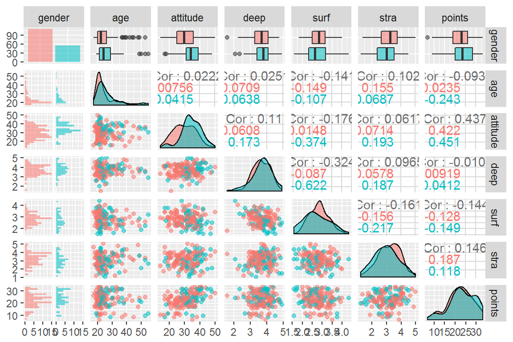

```r
p <- ggpairs(rawdata, mapping = aes(col = gender, alpha = 0.3), lower = list(combo = wrap("facethist", bins = 20)))
p
```

From the graphical representation of the data we can see that that there is a moderate positive correlation between exam points and attitude ($\mathit{r}=.44$), while the correlation of other variables with exam points is very weak. ($\mathit{r} <.2$) The variables correlate generally quite weakly, the exception being the weak negative correlation between surface learning with deep learning ($\mathit{r} = -.32$)

Especially interesting is the relationship between age and all the numeric variables, where only very weak correlations can be found. ($\mathit{r} \le \pm .141$)

Next we’ll take a look at the summaries of the variables.

```r
summary(rawdata)
```

```
##  gender       age           attitude          deep            surf
##  F:110   Min.   :17.00   Min.   :14.00   Min.   :1.583   Min.   :1.583
##  M: 56   1st Qu.:21.00   1st Qu.:26.00   1st Qu.:3.333   1st Qu.:2.417
##          Median :22.00   Median :32.00   Median :3.667   Median :2.833
##          Mean   :25.51   Mean   :31.43   Mean   :3.680   Mean   :2.787
##          3rd Qu.:27.00   3rd Qu.:37.00   3rd Qu.:4.083   3rd Qu.:3.167
##          Max.   :55.00   Max.   :50.00   Max.   :4.917   Max.   :4.333
##       stra           points
##  Min.   :1.250   Min.   : 7.00
##  1st Qu.:2.625   1st Qu.:19.00
##  Median :3.188   Median :23.00
##  Mean   :3.121   Mean   :22.72
##  3rd Qu.:3.625   3rd Qu.:27.75
##  Max.   :5.000   Max.   :33.00
```